# Data Visualization with Economic Indicators

Efe Ahmet Guden

4/19/2021

# Introduction

Recently, Turkish economy suffers from high inflation and high unemployment rates. Therefore, in this paper, three macroeconomic indicators of Turkish economy are inspected: TL per USD exchange rate, consumer price index and unemployment rate. The relationship between actual data and the search volume of related keywords are analyzed. The time-series data of these indicators are imported from [EVDS](https://evds2.tcmb.gov.tr/). EVDS is the official data delivery webiste of Central Bank of the Republic of Turkey. The time-series data of these indicator’s search volumes are imported from [Google Trends](https://trends.google.com/trends/). The wikipedia definition of Google Trends is: “Google Trends is a public web facility of Google Inc., based on Google Search that shows how often a particular search-term is entered relative to the total search-volume across various regions of the world, and in various languages.” The scope of this analysis is from January 2018 to January 2021. The data from Google Trends are collected on a weekly basis. EVDS data for exchange rate are collected on a daily basis. EVDS data for consumer price index and unemployment rate are collected on a monthly basis.

# 1) Exchange Rate

Tl per USD exchange rate is an important measure for Turkish economy since most of the imported goods are purchased with USD. Thus, an increase in the exchange rate may cause an increase in consumer price index, which is an indicator of cost of living. The relationship between actual exchange rate and the search volume of the keyword “dolar kuru” will be analyzed.

## 1.1) Importing Data from EVDS

[EVDS package](https://algopoly.github.io/EVDS/index.html.) is used for importing data from EVDS.

Exchange rate data on holidays and weekends are missing. Those rows have to be excluded from the data in order to perform an analysis.

After some manipulations the data looks like this:

```
##         Date ExchangeRate
## 1 2018-01-15       3.7622
## 2 2018-01-16       3.7593
## 3 2018-01-17       3.8150
## 4 2018-01-18       3.8143
## 5 2018-01-19       3.7967
## 8 2018-01-22       3.7777
```

## 1.2) Importing Data from Google Trends

The data from Google Trends are first downloaded as a csv file. Then the function read.csv() is used for importing the Google Trends data to R.

After some manipulations the data looks like this:

```
##         Date SearchVolume
## 1 2018-01-21            4
## 2 2018-01-28            3
## 3 2018-02-04            3
## 4 2018-02-11            3
## 5 2018-02-18            3
## 6 2018-02-25            3
```

## 1.3) Exchange Rate Data Visualization

The data are visualized with the ggplot() function, which is a function from the ggplot2() package.

This plot shows the TL per USD exchange rate over time.

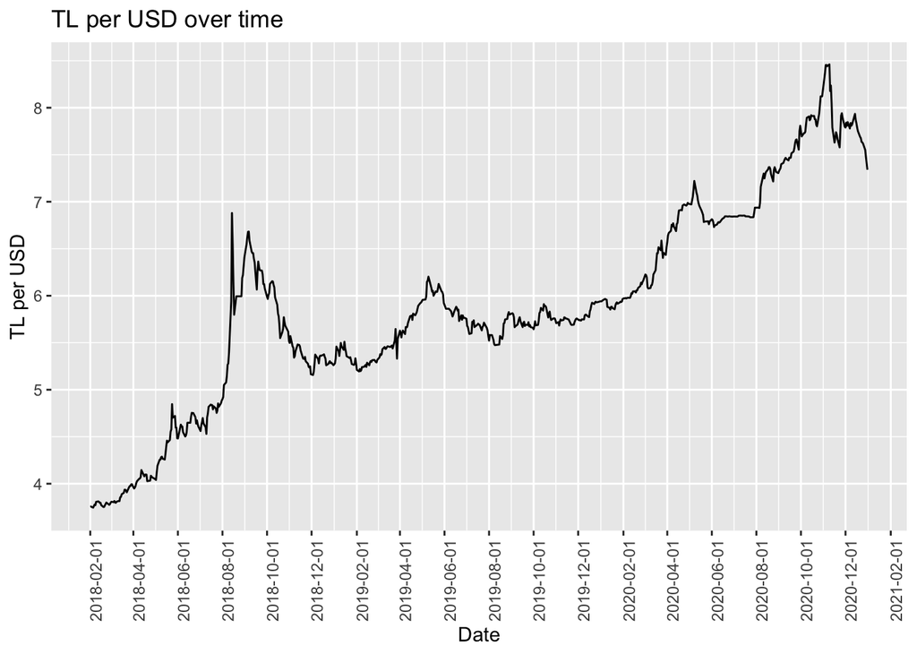

The relationship between the actual exchange rate and the search volume for the keyword “dolar kuru” will be analyzed with the following plots.

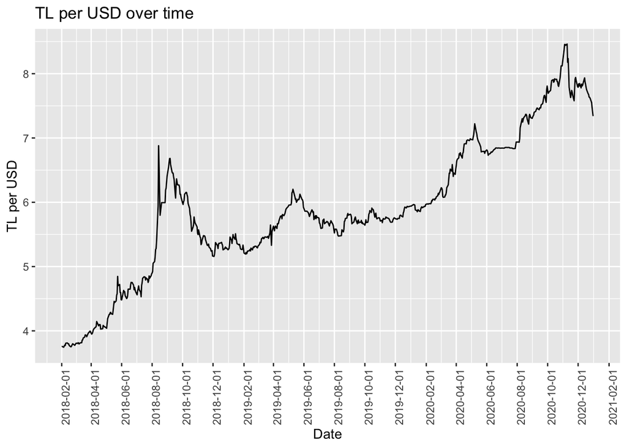

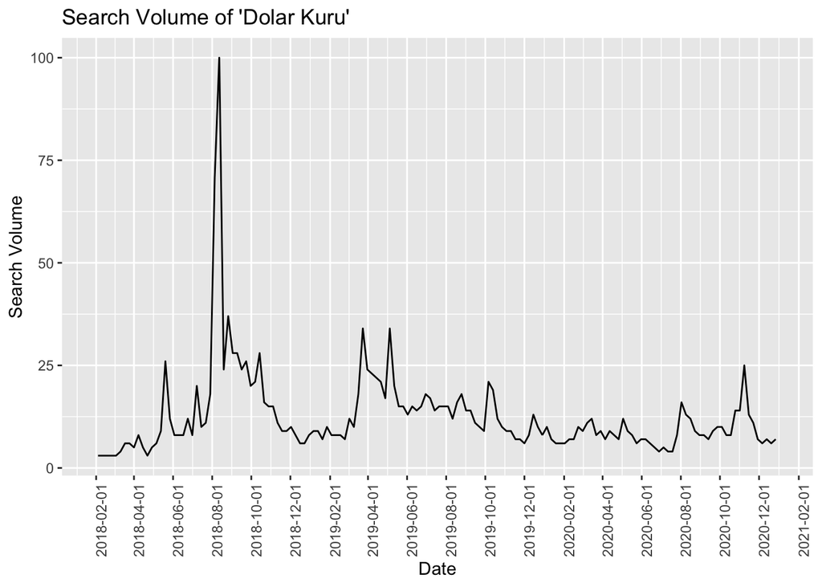

# 2)Consumer Price Index

Consumer price index (CPI) is an indicator of cost of living. Inflation is calculated by the increase in CPI. Thus, one can state that there is high inflation, when the CPI increases rapidly. The relationship between actual CPI and the search volume of the keyword “enflasyon” will be analyzed.

## 2.1) Importing Data from EVDS

[EVDS package](https://algopoly.github.io/EVDS/index.html.) is used for importing data from EVDS.

After some manipulations the data looks like this:

```
##         Date    CPI
## 1 2018-01-15 330.75
## 2 2018-02-15 333.17
## 3 2018-03-15 336.48
## 4 2018-04-15 342.78
## 5 2018-05-15 348.34
## 6 2018-06-15 357.44
```

## 2.2) Importing Data from Google Trends

The data from Google Trends are first downloaded as a csv file. Then the function read.csv() is used for importing the Google Trends data to R.

After some manipulations the data looks like this:

```
##         Date SearchVolume
## 1 2018-01-21            5
## 2 2018-01-28           10
## 3 2018-02-04           10
## 4 2018-02-11            5
## 5 2018-02-18            4
## 6 2018-02-25            8
```

## 2.3) CPI Data Visualization

This plot shows the consumer price index over time.

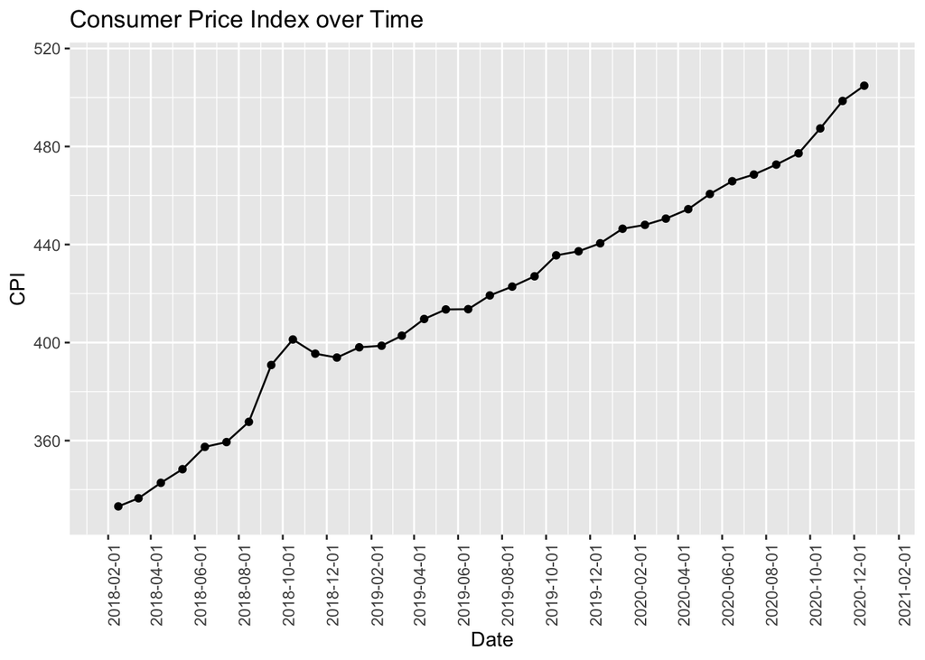

One can observe that there is an increasing trend. The increase in the consumer price index means that the price levels are increasing, thus the cost of living is increasing. Notice that there is a jump in 2018 September. Therefore, there is high inflation in 2018 September. The cause of this jump may be dramatic increase in the exchange rate which happened in 2018 August.

The relationship between the CPI and the search volume for the keyword “enflasyon” will be analyzed with the following plots.

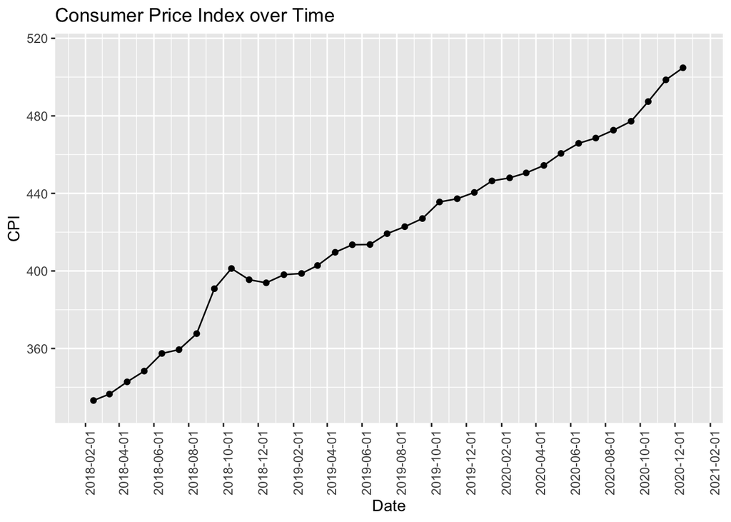

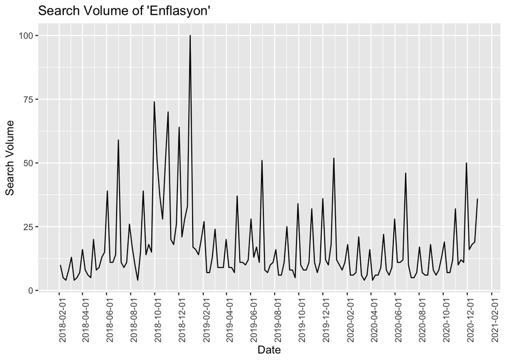

# 3) Unemployment Rate

Unemployment rate is an indicator which measures the ratio of number of unemployed people to the number of people who are in the labour force. Turkish economy suffers from high unemployment rates, which leads to problems both economically and socially. The relationship between unemployment rate and the search volume for the keyword “işsizlik oranı” will be analyzed.

## 3.1) Importing Data from EVDS

[EVDS package](https://algopoly.github.io/EVDS/index.html.) is used for importing data from EVDS.

After some manipulations the data looks like this:

```
##         Date UnemployementRate
## 1 2018-01-15              11.0
## 2 2018-02-15              10.8
## 3 2018-03-15               9.8
## 4 2018-04-15               9.3
## 5 2018-05-15               9.4
## 6 2018-06-15              10.2
```

## 3.2) Importing Data from Google Trends

The data from Google Trends are first downloaded as a csv file. Then the function read.csv() is used for importing the Google Trends data to R.

After some manipulations the data looks like this:

```
##         Date SearchVolume
## 1 2018-01-21            0
## 2 2018-01-28           22
## 3 2018-02-04           21
## 4 2018-02-11           10
## 5 2018-02-18           11
## 6 2018-02-25           26
```

## 3.3) Unemployment Rate Data Visualization

This plot shows the unemployment rate over time.

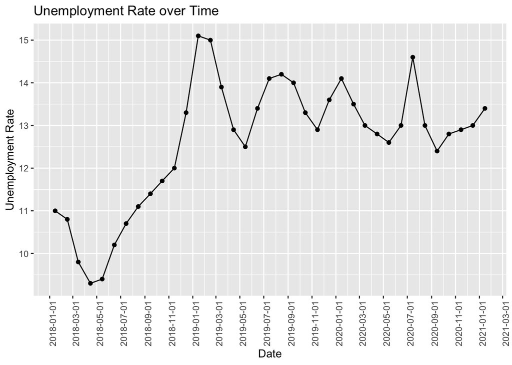

The relationship between unemployment rate and the search volume for the keyword “işsizlik oranı” will be analyzed with the following plots.

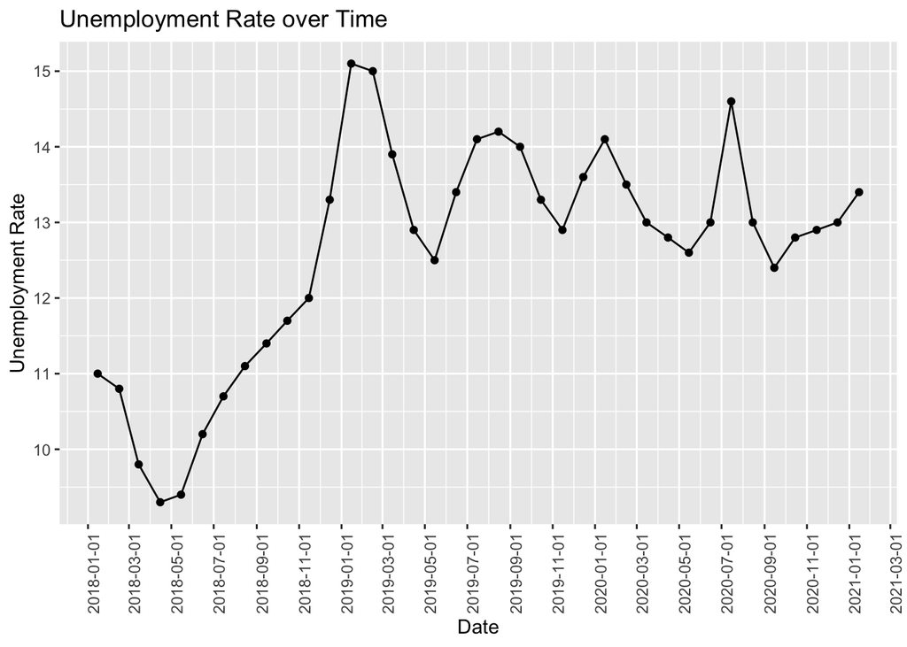

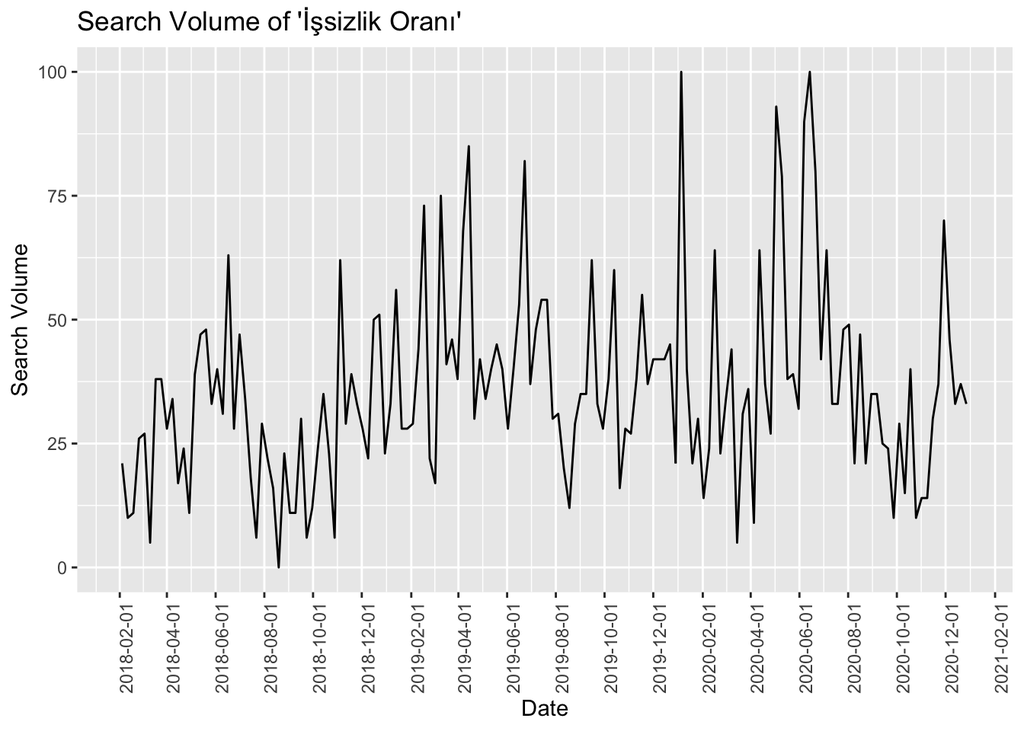

# Conclusion

Three macroeconomic indicators of Turkish economy is inspected. The relationship between the actual data and the search volume of related keywords are analyzed. One can observe that the dramatic increase in an economic indicator leads to a dramatic increase in search volume. To conclude, there is a relationship between actual data and the serach volume of related keywords.